# Using Containers to Validate Research on Confidential Data at Scale

Lars Vilhuber

May 2024

# Introduction

## Concerns

Concerns about confidentiality in statistical products have increased in the past several years:

- New disclosure avoidance techniques in the Decennial Census garnered much attention (an understatement…),
- also concerns about formal disclosure avoidance techniques for public-use microdata files (PUMFs) (see [Census Bureau delayed implementation of such methods for the American Community Survey](https://www.census.gov/newsroom/blogs/random-samplings/2022/12/disclosure-avoidance-protections-acs.html))

## Validation and Verification

On the other hand,

- long-running pilot projects with (non-formal) synthetic microdata products (SynLBD, SIPP Synthetic Beta) came to an end in 2022 ([End of life for the Cornell Synthetic Data Server September 30, 2022](https://web.archive.org/web/20230602202220/https://web.archive.org/web/20221130032540/https://www2.vrdc.cornell.edu/news/))
- not sure how active OPM Verification server was (Barrientos et al (2018))

## Scaling up

These pilot projects were not set up to scale, and yet they demonstrated that there is a need for such a process.

# Background

## Anecdotal evidence with SDS

From conversations/informal surveys:

- researchers were happy with the ability to access data without having to request a full-blown project in an FSRDC
- somewhat frustrated by the process (slowness)

## Reproducibility and SDS

SDS validation required typically substantial human debugging

- Reason: problems with the reproducibility of code in the social sciences despite similarity of environment.

## Intermediate causes

- no strong pre-testing of reproducibility, often intense use of interactive programming practices
- divergence in environments over time
- divergence of data schemas over time

**Failure to maintain strong links**

## Some broader evidence

In a sample of over **8,000 replication packages** associated with high-profile economics articles, **only 30% had some sort of master script**.

## Other systems

Statistical agencies and research institutes have explored various ways to scale up access to confidential data, without full (remote) access to confidential data.

- Statistics Canada: [Real Time Remote Access (RTRA)](https://www.statcan.gc.ca/en/microdata/rtra) process,
- Norway: Microdata.no system,
- Germany/IAB: [JoSuA system](https://fdz.iab.de/en/data-access/on-site-use/)

## Access restrictions

Most such processes have limitations, including in their utility for general purpose analysis

Most still have some **strong access limitations**

- RTRA: organizational application process
- microdata.no: Institutional MOU (and only Norwegian residents)
- IAB: proposal process

## Analysis restrictions

Many systems strongly **limit the type of analysis** that is feasible by

- RTRA: restricting the software keywords that can be used, subset of SAS allowing to “calculate frequencies, means, percentiles, percent distribution, proportions, ratios and shares.
- microdata.no: by creating a structured new statistical language (albeit with increasingly sophisticated capabilities)

## Comparison

The comparison researchers and analysts make is (for right or wrong) to the **unfettered use of public-use data**…

# The quest

## Direct access is expensive

Remote-access or local secure access in the form of physical or virtual secure data enclaves is still the dominant - **but expensive** - way to access confidential data.

> The dominant method of access thus forces researchers to choose between lower quality data in an environment that corresponds to their preferred computing method, and higher quality confidential data in environments that are expensive for researchers, data providers, or both.

# Possible solution

## Containerized validation

We demonstrate a simple scenario of using containers, which can be hosted on a cloud platform, but also run individually on researcher compute platforms, to facilitate synthetic and confidential data processing. The purpose of using containers is to provide users with access to synthetic data and coding resources such that their analysis is easily reproducible. Containers can easily be validated for reproducibility before they are then forwarded to the confidential computing environment. Once determined to be reproducible, extending the analysis to use confidential data, and enables a wide spectrum of plug-in disclosure avoidance measures as well. Crucially, all validation of reproducibility can be performed prior to validation using the confidential data, on open, possibly commercial platforms. Only once reproducibility is confirmed is the same analysis model ported to the confidential data.

- similar in spirit: IAB JoSuA system

## Containers in the wild

One of the first mentions of containers for scientific research was Boettiger (2015).

The use of cloud providers removes the need for users of the synthetic to install anything locally. The use of containers enforces reproducibility out-of-box when using synthetic data, as well as streamlines validation against the confidential data (which is in essence a replication of the analysis on the synthetic data). Furthermore, it enables scalability. CodeOcean is a commercial service facilitating that process by making the resources available through a web browser, though the basic functionality can be achieved on any container system. Options include [Wholetale](https://wholetale.org), and others.[^1] Finally, users who wish to not use such services can also typically provide their own setup for the synthetic data component, at very little additional cost or effort. Many university computing system provide some support on their high-performance computing clusters. For data providers, the tools used (containers) are widely used by numerous cloud providers, are transparent in how they are built, and allow for in-depth security scanning while retaining much of the flexibility that researchers and IT providers seek.

## Containers in Social Sciences is still a challenge!

In a sample of over **8,000 replication packages** associated with high-profile economics articles, **only 11 had a `Dockerfile`** (the key build script for containers).

(That’s n=11, not 11% - in fact, it’s **0.13%** of replication packages.)

## What’s new

The use of containers in this way is novel as a systematic way to provide scalable, potentially high-throughput validation, and differs in usage from previous methods, such as the Cornell Synthetic Data Server.

I believe that it is promising as a modern way of implementing validation when data are confidential.

# User perspective

## Use provided container with pre-provisioned data

Possibilities:

- use directly (*safer*)
- use as input to build own container (addition of components)

## Critically

Pre-provisioned data does not need to be “**analytically valid**” - need only be “**plausible**”!

## Develop where feasible

Containers are generalized technology

- can be run on provisioned university computing infrastucture (most HPC systems can run containers)
- can run on desktops as needed (free container software available for all major operating systems for non-commercial use)
- can run on generic cloud infrastructure (AWS, Google Cloud, Azure)
- can run on custom cloud infrastructure specialized in running containers ([Nuvolos](https://nuvolos.cloud), [Codeocean](https://codeocean.com), etc.)
- can be prepared by research institutions for use on their custom infrastructure (e.g., NSF-funded [Whole Tale project](https://wholetale.org))

## Whole Tale

[figure not shown]

## Cost to user

Cost: $0 to low $

## Run a container from the command line

```r
## read the file run_docker.sh
tail(readLines("run_docker.sh"),n=1)
```

[output not shown]

## Run a container from Codeocean

[figure not shown]

[figure not shown]

## Develop at will

- Arbitrary Stata, R, Python, etc. code

## Submit for validation

- Submit container *recipe* (`Dockerfile`) and code for validation to *StatAgency.gov*

```
./Dockerfile
./code/01_prepare_data.R
./code/02_run_analysis.R
./code/03_create_figures.R
```

# Provider perspective: Secure build

## First impressions

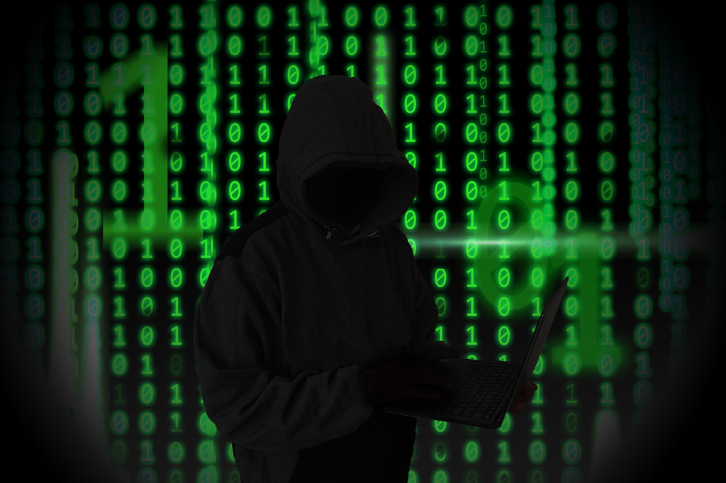

[^2]

## Internal build

- Prepare an internal container, compliant with IT security standards
  - secure configuration of container running system (base system)
  - add layer of common software (Stata, R, Python, various combinations) for **analysis system**
  - test suite (scripted) for updates
- Can leverage existing container recipes for well-known software packages (`rocker` for R containers, datascience containers)
- Can leverage existing containers and harden the OS (if necessary)

## Public build

- Public “recipe” is the same as for internal
  - possibly up to secure base container - close enough is good enough
  - built by StatAgency itself

## Example: Build internal analysis system

```
FROM registry.internal.statagency.gov/os/ubuntu-24.04-secured

# Install Stata from internal sources (simple tar file), no license
...
# Install R from internal sources
...
USER rstudio
```

## Example: Build public analysis system

```
FROM ubuntu-24.04

# Install Stata from internal sources (simple tar file), no license
...
# Install R from internal sources
...
USER rstudio
```

## Optional elements

While not strictly necessary, containers might contain

- development environments (Stata GUI, Jupyter notebooks, Rstudio)
- standard set of libraries (Stata ado files, R libraries, Python packages)

## Public posting

Prepared containers and recipes can be posted on public registries:

- post container on public registry ([Docker Hub](https://hub.docker.com), [Google Container Registry](https://cloud.google.com/container-registry), etc.)
- post recipe on public repository ([GitHub](https://github.com), [GitLab](https://gitlab.com), etc.)

## Posted on Docker Hub

[figure not shown]

# References

Boettiger, Carl. 2015. “An Introduction to Docker for Reproducible Research.” *ACM SIGOPS Operating Systems Review* 49 (1): 71–79. https://doi.org/10.1145/2723872.2723882.

[^1]: An earlier version of this presentation mentioned [Gigantum](https://gigantum.com). As is not unusual in this space, Gigantum no longer functions as a company.
[^2]: Image credit [Christopher Scholz](https://www.flickr.com/photos/140988606@N08/27509199696), under [CC-By-SA 2.0](https://creativecommons.org/licenses/by-sa/2.0/)